# ECO-MRIO-SFC Model: 54-Sector Version Documentation

Oriol Vallès Codina

2024-08-12

# Introduction

# Initialization

The initial values and variables are loaded from the file stored in variable `identif` in a different structure as before.

```r
# Clear Environment
rm(list = ls())

# Load Auxiliary Functions
directory <- '' # '' for the markdown file, 'flexible_/' for R
variable.table <<- read.csv(paste0(directory, 'data/Variable_Definitions.csv'))
source(paste0(directory, 'functions/auxiliary_flexible_aug12.R')) # load.new.init, auxiliary labeling functions, plotting function

# Load Initial Values
identif <- paste0(directory, 'data/perfect_init_aug9_withBmatrix.xlsx')
initial <- load.new.init(identif)

# Load Models
source(paste0(directory, "functions/run_new_model_aug9.R")) # function run.new.model(initial.values, model.equations)
source(paste0(directory, "functions/MVP_model_aug9.R")) # model equations

# baseline <- run.new.model(initial, mvp.model)
# saveRDS(baseline, file = 'data/baseline_aug9.RDS')
baseline <- readRDS(file = 'data/baseline_aug9.RDS')
```

## Contents of `initial`

- `variables`, a list of global, aggregate (country-level), and industry-level variables that are saved in `initial` in the data frame `vars`, the initial state vector, (previously `init.table`)
- `parameters`, a list of global and aggregate (country-level) parameters that are saved in `initial` in the data frame `pars`,
- `identif`, which saves the name of the Excel file for reference and documentation purposes: data/perfect_init_aug9_withBmatrix.xlsx,
- `countries`, the country labels that are taken from the $A$ matrix row names (left to the dot `.`): EU, RoW
- `sectors`, the industry labels that are taken from the $A$ matrix row names (right to the dot `.`)
- `N`, the number of countries (a scalar), $N = 2$,
- `K`, the number of industries in each country (a vector), $K = 54$, and

Its dimension is the number of global variables 1 plus the number of aggregate variables 107 times the number of countries 2 plus the number of industry variables 49 times the number of countries 2 times the number of industries 54:

```r
nrow(initial$variables$global) + nrow(initial$variables$aggregate) * initial$N + nrow(initial$variables$industry) * unique(initial$K)
```

```
## [1] 5507
```

# Table of Industries

```r
kable(data.frame(number = 1 : length(initial$sectors), industry = initial$sectors),
      booktabs = T)
```

| number | industry |
| --- | --- |
| 1 | Agriculture |
| 2 | Animal Farming |
| 3 | Forestry, logging and related service activities (02) |
| 4 | Fishing, operating of fish hatcheries and fish farms; service activities incidental to fishing (05) |
| 5 | Extraction of Fossil-Fuels |
| 6 | Mining & Quarrying of raw materials |
| 7 | Processing of meat |
| 8 | Processing of other food&beverage |
| 9 | Manufacture of tobacco products (16) |
| 10 | Manufacture of textiles |
| 11 | Manufacture of wood and of products of wood and cork, except furniture; manufacture of articles of straw and plaiting materials (20) |
| 12 | Re-processing of secondary wood material into new wood material |
| 13 | Pulp |
| 14 | Re-processing of secondary paper into new pulp |
| 15 | Paper |
| 16 | Processing of Fossil Fuels |
| 17 | Plastics, basic |
| 18 | Re-processing of secondary plastic into new plastic |
| 19 | Manufacture of Chemicals |
| 20 | Manufacture of rubber and plastic products (25) |
| 21 | Manufacture of glass and glass products |
| 22 | Re-processing of secondary glass into new glass |
| 23 | Manufacture of other non-metallic mineral products |
| 24 | Manufacture of cement, lime and plaster |
| 25 | Re-processing of ash into clinker |
| 26 | Manufacture of Metals |
| 27 | Re-processing of Metals |
| 28 | Manufacture of durable goods |
| 29 | Manufacture of furniture; manufacturing n.e.c. (36) |
| 30 | Recycling |
| 31 | Production of electricity by fossil fuels |
| 32 | Production of electricity by renewable energy |
| 33 | Transmission & Distribution |
| 34 | Manufacture of gas; distribution of gaseous fuels through mains |
| 35 | Water |
| 36 | Construction (45) |
| 37 | Re-processing of secondary construction material into aggregates |
| 38 | Sale, maintenance, repair of motor vehicles, motor vehicles parts, motorcycles, motor cycles parts and accessoiries |
| 39 | Retail sale of automotive fuel |
| 40 | Retail & Wholesale trade |
| 41 | Leisure Services |
| 42 | Transport |
| 43 | KIBS |
| 44 | Real estate activities (70) |
| 45 | Renting of machinery and equipment without operator and of personal and household goods (71) |
| 46 | Research and development (73) |
| 47 | Public administration and defence; compulsory social security (75) |
| 48 | Education (80) |
| 49 | Health and social work (85) |
| 50 | Incineration of Waste |
| 51 | Biogas & Composting |
| 52 | Waste water |
| 53 | Landfill of Waste |
| 54 | Other Services |

# MRIO $A$ Matrix Visualization

Importantly, the column names of the $A$ matrix contained in `identif` determine the country and industry labels in the whole model, following the grammar `country_label.industry_label`:

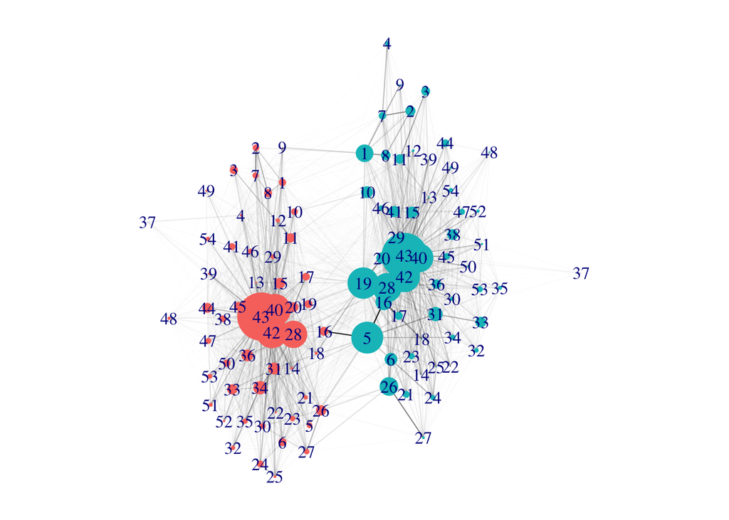

```r
library(igraph)
library(qgraph)
go <- rowSums(initial$A.matrix)
g <- graph_from_adjacency_matrix(as.matrix(initial$A.matrix),
                                 mode = 'directed', weighted = TRUE,diag = F, add.colnames = T)

# Graph Visualization
l <- qgraph.layout.fruchtermanreingold(get.edgelist(g, names=FALSE), vcount=vcount(g))
V(g)$size <- 7.5 * go ^ 0.75
V(g)$frame.color <- NA
# V(g)$name <- apply(expand.grid(1 : unique(initial$K), initial$countries)[c(2,1)], 1, function(x) paste0(x, collapse = ""))
V(g)$name <- rep(1 : unique(initial$K), times = 2)
V(g)$color <- rep(scales :: hue_pal()(4)[c(1, 3)], each = unique(initial$K))
E(g)$color <- alpha('black', E(g)$weight / max(E(g)$weight))

par(mar = c(0,0,0,0))
plot(g, edge.arrow.size = 0)
```

```r
# title("MRIO (EU, red; RoW, emerald)")
```

# Calibration

## Load Targets

Target values are loaded in format long (`target.set`) and wide (`target.table.0`). Units are divided by 10,000 for convenience.

```r
#### LOAD TARGET VALUES ####
target.list <- load.target(paste0(directory, 'data/target_values.xlsx'))
target.table <- target.list$wide
target.set <- target.list$long
target.vars <- target.set$var.label
```

## Target Values

```r
target.set$target <- baseline$simulation[target.set$var, baseline$initial$pars['nPeriods', 'value']]
target.set$ratio <- round(target.set$target / target.set$value, 2)

compute.target(baseline)
```

```
## $table
##              Z1_c        Z2_c       Z1_id      Z2_id       Z1_g        Z2_g
## value  626.317880 2370.705952 196.6150852 908.672096 239.459251 675.3283891
## target 639.442534 2490.186243 193.4427224 926.058386 240.000000 675.0000000
## ratio    1.020955    1.050399   0.9838651   1.019134   1.002258   0.9995137
##            Z1_rex     Z2_rex     Z1_imp     Z2_imp Z1_M_TOT_int Z2_M_TOT_int
## value  102.775931 66.3570804 66.3570804 102.775931   123.151817   105.854567
## target 103.050978 60.7293075 60.7293075 103.050978   125.474198   108.929424
## ratio    1.002676  0.9151896  0.9151896   1.002676     1.018858     1.029048
##              Z1_fd       Z2_fd       Z1_va       Z2_va       Z1_go       Z2_go
## value  1098.811066 3918.287587 1081.513816 3935.584836 2153.602494 8424.517003
## target 1165.206927 4278.922959 1237.843213 4580.169886 2188.158529 8687.182370
## ratio     1.060425    1.092039    1.144547    1.163784    1.016046    1.031179
##            Z1_gdef    Z2_gdef Z1_debt_gdp Z2_debt_gdp      Z1_b_s      Z2_b_s
## value   0.25000000  0.2500000    0.800000    0.600000 1373.000000 5040.000000
## target -0.02477849 -0.1872231    1.109977    1.101777 1373.977228 5046.325726
## ratio  -0.09911398 -0.7488925    1.387471    1.836295    1.000712    1.001255
##
## $total.fit
## [1] 0.2165201
##
## $fitness
## [1] 0.2165201
```

# Visualization

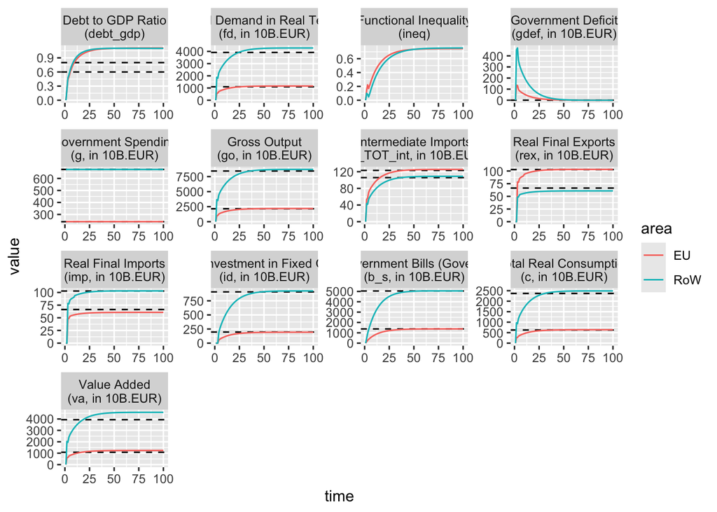

```r
plot.vars(baseline, c(target.vars, 'ineq', 'debt_gdp'))
```

# Shocks

```r
selected <- c('n', 'c', 'ineq', 'va', 'cab', 'nf', 'gdef', 'tb', 'go')
macro.vars<-c('c', 'rva', 'go','id')
external.vars<-c('cab','gdef','tb')
social.vars <- c('n', 'nf', 'ineq')
prices.vars<- c('pa','pid','pg','pim')
employment.vars<-c('n', 'nf')
inequality.vars<-c('ydw','ydc','ineq')
debt.wealth.vars<-c('lh','lf','v','k','bs')
```

# Shock Example 7: Product Lifetime Extension

## Run Shock

This is a simple visualization of shock 7. Please note the new grammar to change initial values.

```r
# Time Period Selection
t.shock <- initial$pars['t.shock', 'value'] # shock time period
t0 <- 50 # initial time period for visualization
tf <- initial$pars['nPeriods', 'value'] # final time period for visualization

# Shock Selection and Run
initial$pars['shock', 'value'] <- 7 # shock 7
# ple.shock <- run.new.model(initial, mvp.model)

# saveRDS(ple.shock, file = 'data/pleshock_aug12.RDS')
ple.shock <- readRDS(file = 'data/pleshock_aug12.RDS')

shock.title <- 'Shock: Product Lifetime Extension'
df <- shock.long.new(baseline, ple.shock)
```

## Visualize Shocked Variables

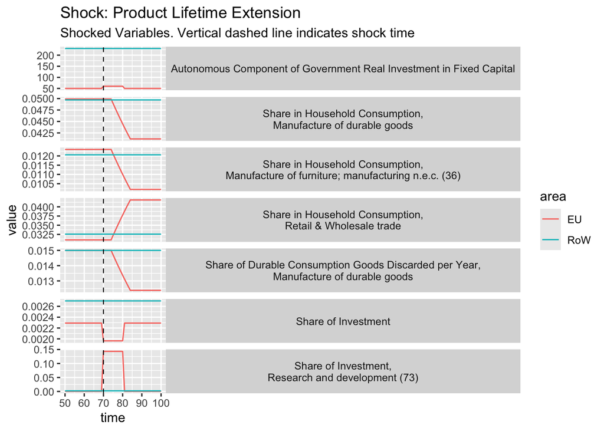

```r
view.shock(ple.shock,
           shock.vars = c('id0', 'iota_g-1', 'iota_g-46', 'zeta_dc-28', 'beta-28', 'beta-29', 'beta-40'),
           shock.sectors = c(NA, NA, 46, 28, 28, 29, 40))
```

## Visualize Scaled Variables

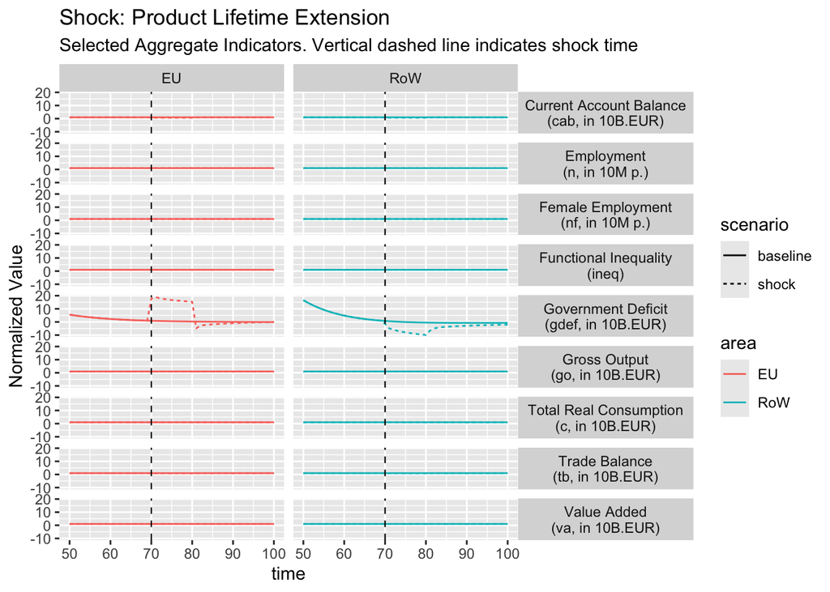

```r
# Selected Vars to plot
view.vars(data = df,
          viz.vars = selected,
          var.label = '')
```

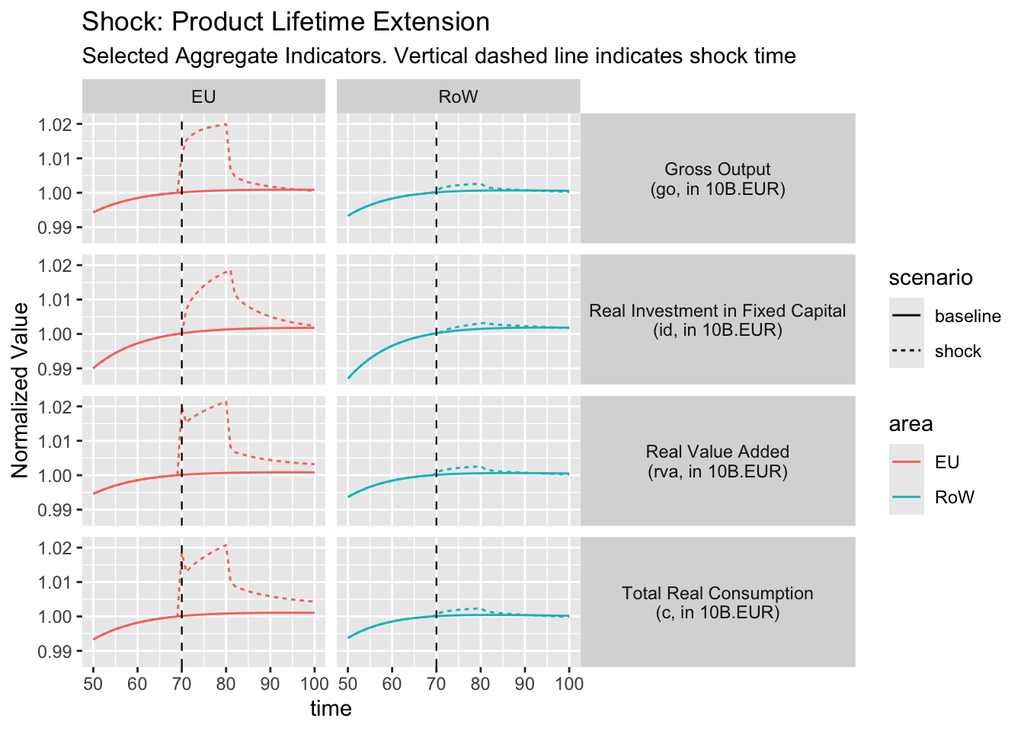

```r
# Macroeconomic Vars to plot
view.vars(data = df,
          viz.vars = macro.vars,
          var.label = 'Macroeconomic')
```

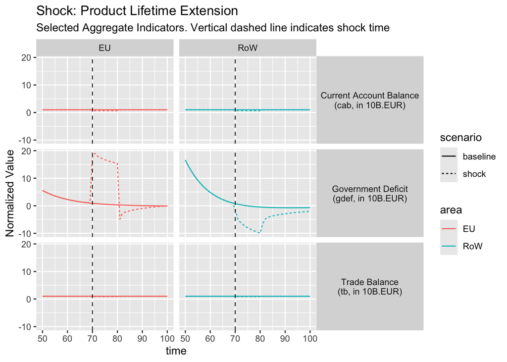

```r
# External Vars to plot
view.vars(data = df,
          viz.vars = external.vars,
          var.label = 'External')
```

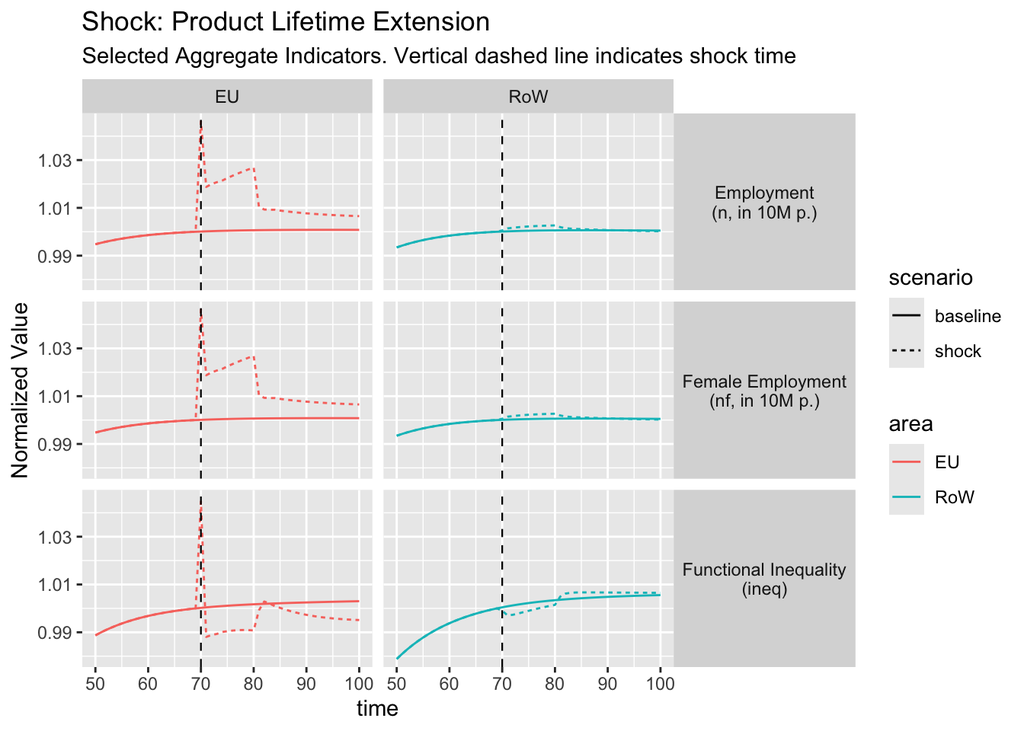

```r
# Social Vars to plot
view.vars(data = df,
          viz.vars = social.vars,
          var.label = 'Social')
```

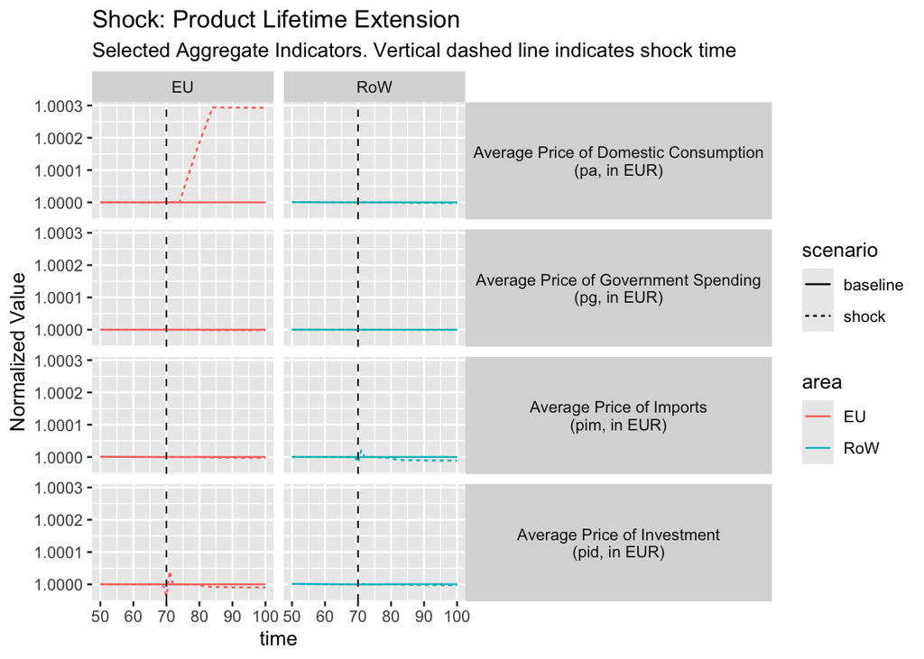

```r
# Price Vars
view.vars(data = df,
          viz.vars = c('pa', 'pid', 'pg', 'pim'),
          var.label = 'Price Indices')
```

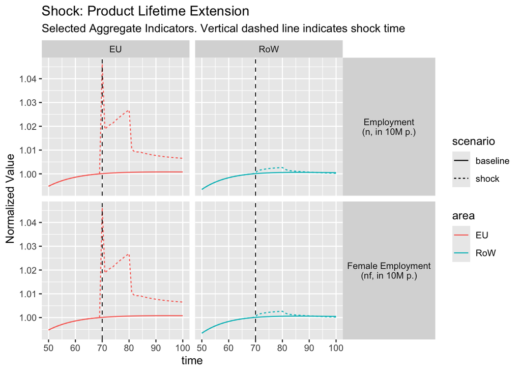

```r
# Employment
view.vars(data = df,
          viz.vars = c('n', 'nf'),
          var.label = 'Employment')
```

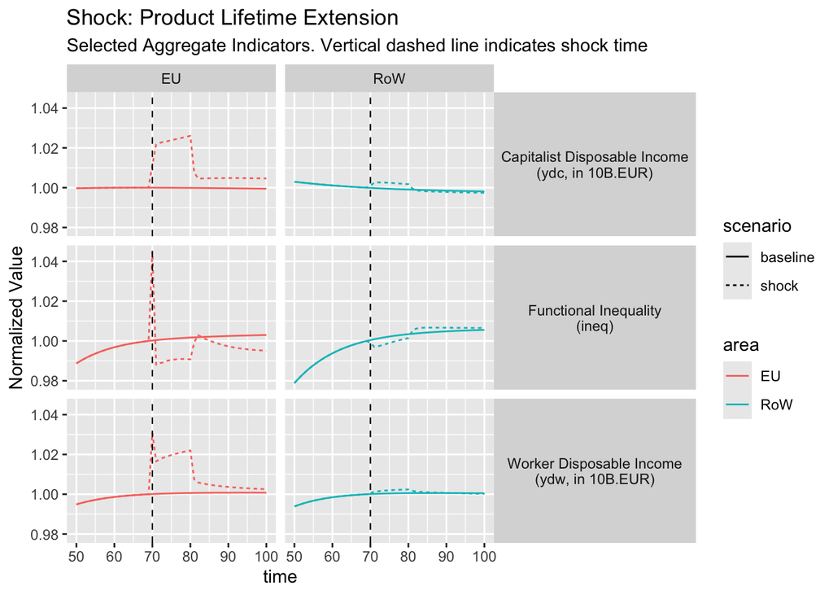

```r
# Inequality
view.vars(data = df,
          viz.vars = inequality.vars,
          var.label = 'Inequality')
```

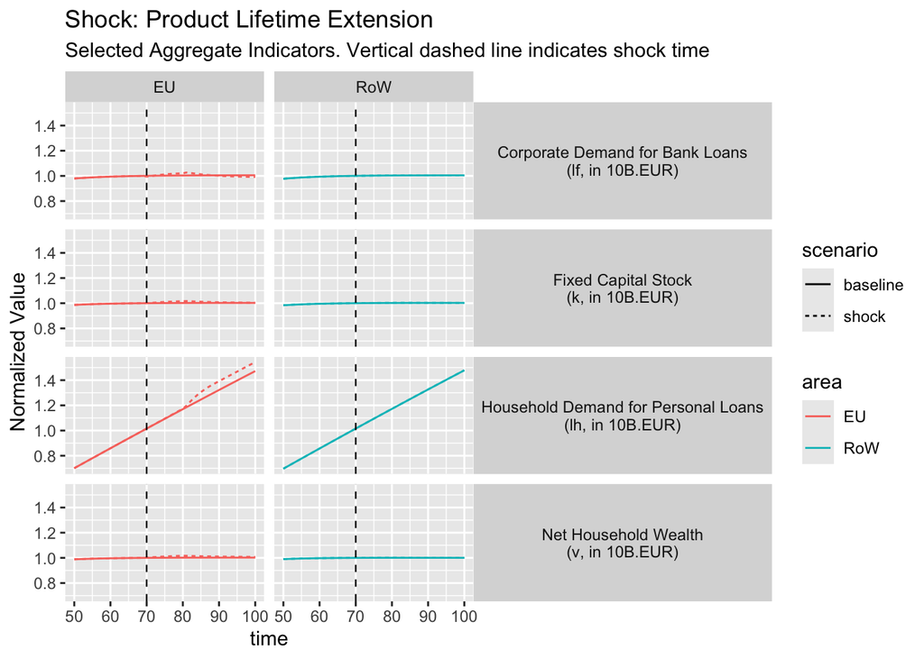

```r
# Debt and Wealth
view.vars(data = df,
          viz.vars = debt.wealth.vars,
          var.label = 'Financial Stocks')
```

## Scaled Visualization

This is a scaled visualization of shock 7.

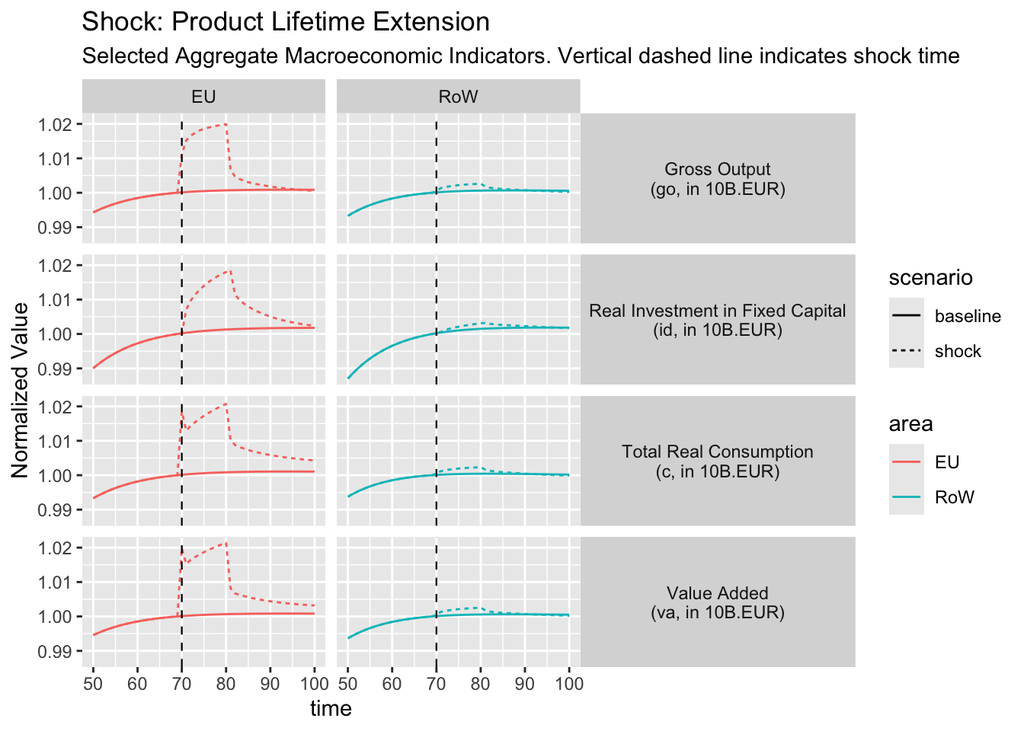

```r
# Variable Selection
macro.vars <- c('c', 'va', 'go','id')
external.vars <- c('cab', 'gdef', 'tb', 'nimp')
social.vars <- c('n', 'nf', 'ineq', 'pa')

# df <- shock.long.new(baseline.54, ple.shock) # already run above
df <- df %>% filter(time >= t0 & time <= tf)
df$ref.value <- rep(filter(df, time == (t.shock - 1)) %>% select(value), times = tf - t0 + 1) %>% unlist
df$norm.value <- df$value / df$ref.value

# Macro Vars
p.macro <- filter(df, variable %in% macro.vars) %>% ggplot(aes(x = time, y = norm.value, color = area, linetype = scenario)) + ylab('Normalized Value') +
  facet_grid(name ~ area) + geom_line() + theme(strip.text.y.right = element_text(angle = 0)) +
  geom_vline(xintercept = t.shock, linetype = 'dashed', linewidth = .4) +
  labs(title = shock.title, subtitle = 'Selected Aggregate Macroeconomic Indicators. Vertical dashed line indicates shock time') + coord_cartesian(xlim = c(t0, tf))

# Social Vars
p.social <- filter(df, variable %in% social.vars) %>% ggplot(aes(x = time, y = norm.value, color = area, linetype = scenario)) + ylab('Normalized Value') +
  facet_grid(name ~ area) + geom_line() + theme(strip.text.y.right = element_text(angle = 0)) +
  geom_vline(xintercept = t.shock, linetype = 'dashed', linewidth = .4) +
  labs(title = shock.title, subtitle = 'Selected Aggregate Social Indicators. Vertical dashed line indicates shock time') + coord_cartesian(xlim = c(t0, tf))

# External Vars
p.external <- filter(df, variable %in% external.vars) %>% ggplot(aes(x = time, y = value, color = area, linetype = scenario)) + ylab('Value') +
  facet_grid(name ~ area, scales = 'free_y') + geom_line() + theme(strip.text.y.right = element_text(angle = 0)) +
  geom_vline(xintercept = t.shock, linetype = 'dashed', linewidth = .4) +
  labs(title = shock.title, subtitle = 'Balance of Payments and Government Balance Indicators. Vertical dashed line indicates shock time') + coord_cartesian(xlim = c(t0, tf))

# Print Plots
print(p.macro)
```

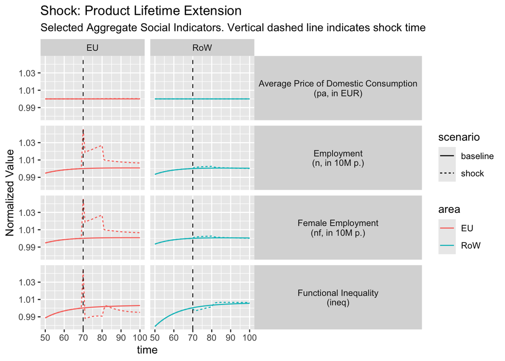

```r
print(p.social)
```

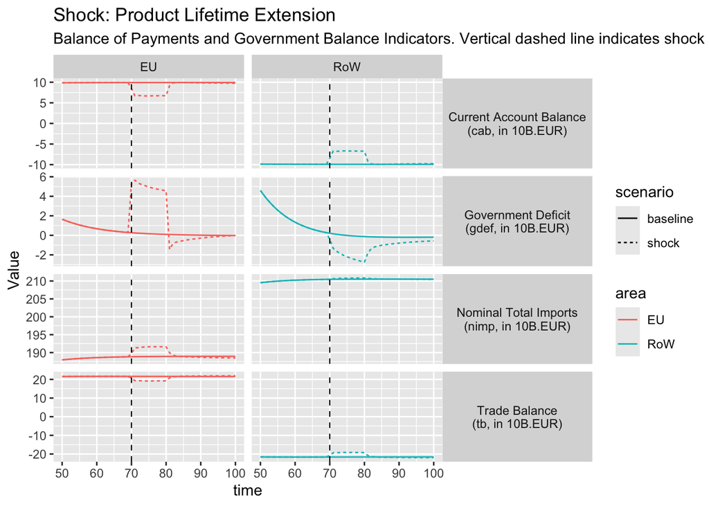

```r
print(p.external)
```

# Shock Example 4: Changing IO Coefficients

## Run Shock

This is a simple visualization of shock 4. Please note the new grammar to change initial values.

```r
# Shock Selection and Run
init.ce <- load.new.init('data/perfect_init_aug11_withBmatrix_CE_inputs_higher_costs.xlsx')
# Time Period Selection
t.shock <- init.ce$pars['t.shock', 'value'] # shock time period
t0 <- 50 # initial time period for visualization
tf <- init.ce$pars['nPeriods', 'value'] # final time period for visualization

init.ce$pars['shock', 'value'] <- 4

# ce.shock <- run.new.model(init.ce, mvp.model)
# saveRDS(ce.shock, file = 'data/CE_shock_aug12.RDS')
ce.shock <- readRDS(file = 'data/CE_shock_aug12.RDS')

shock.title <- 'Shock: Change in IO Coefficients'
df <- shock.long.new(baseline, ce.shock)
```

## Visualize Selected Variables

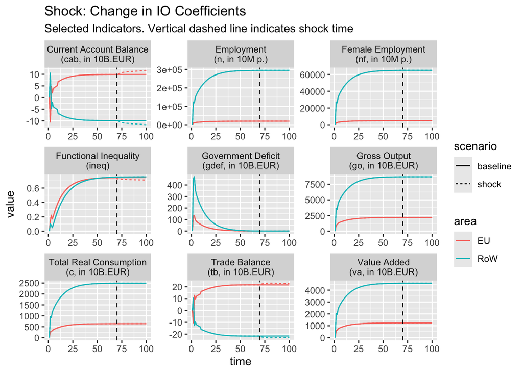

```r
# Selected Vars to plot
selected <- c('n', 'c', 'ineq', 'va', 'cab', 'nf', 'gdef', 'tb', 'go')

p.selected.vars <- filter(df, variable %in% selected) %>%
    ggplot(aes(x = time, y = value, color = area, linetype = scenario)) + facet_wrap(~ name, scales = 'free') + geom_line() +
    geom_vline(xintercept = initial$pars['t.shock', 'value'], linetype = 'dashed', linewidth = .4) +
    labs(title = shock.title, subtitle = 'Selected Indicators. Vertical dashed line indicates shock time')

p.selected.vars
```

## Visualize Scaled Variables

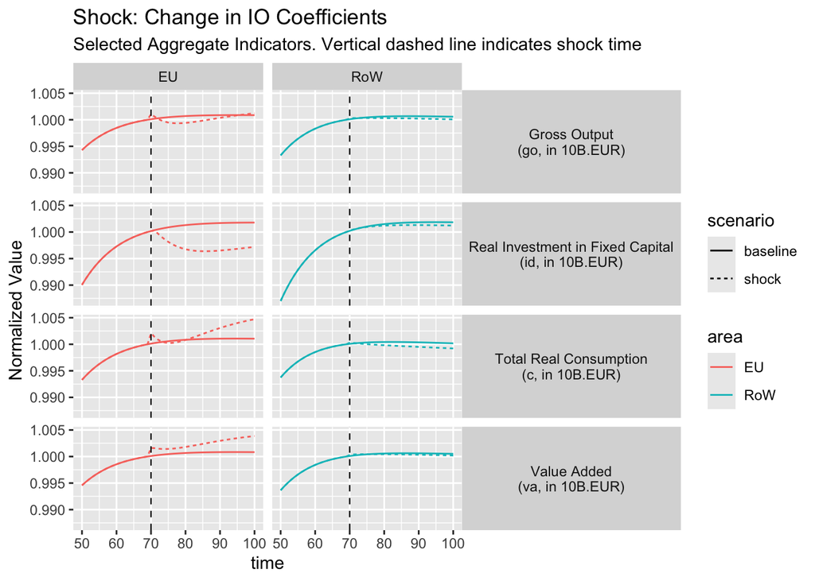

```r
# Macroeconomic Vars to plot
view.vars(data = df,
          viz.vars = macro.vars,
          var.label = 'Macroeconomic')
```

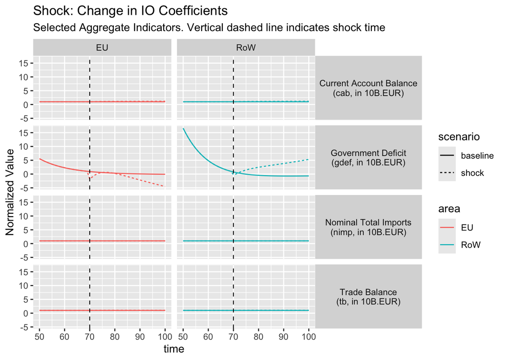

```r
# External Vars to plot
view.vars(data = df,
          viz.vars = external.vars,
          var.label = 'External')
```

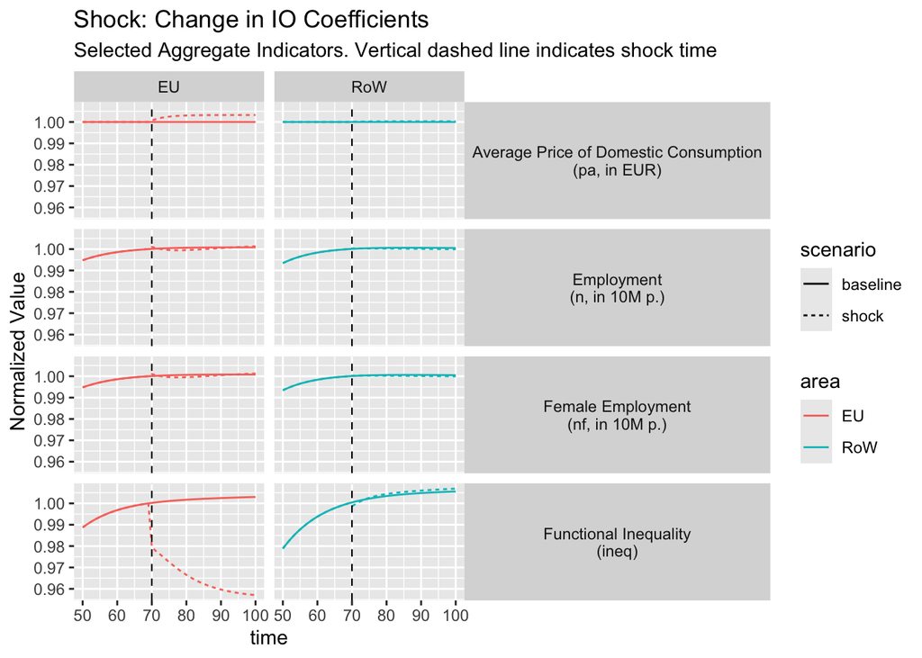

```r
# Social Vars to plot
view.vars(data = df,
          viz.vars = social.vars,
          var.label = 'Social')
```

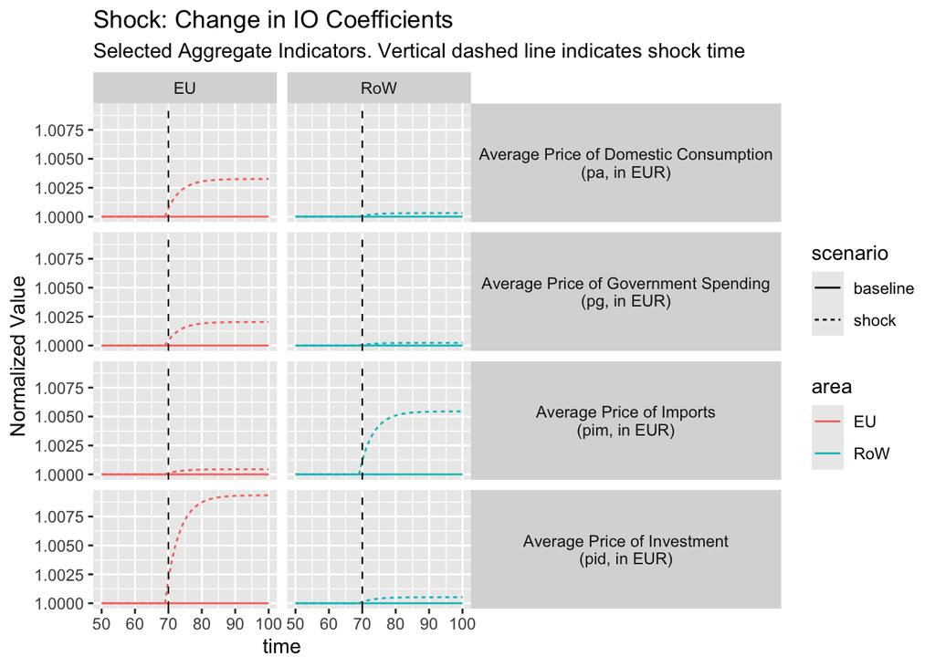

```r
# Price Vars
view.vars(data = df,
          viz.vars = c('pa', 'pid', 'pg', 'pim'),
          var.label = 'Price Indices')
```

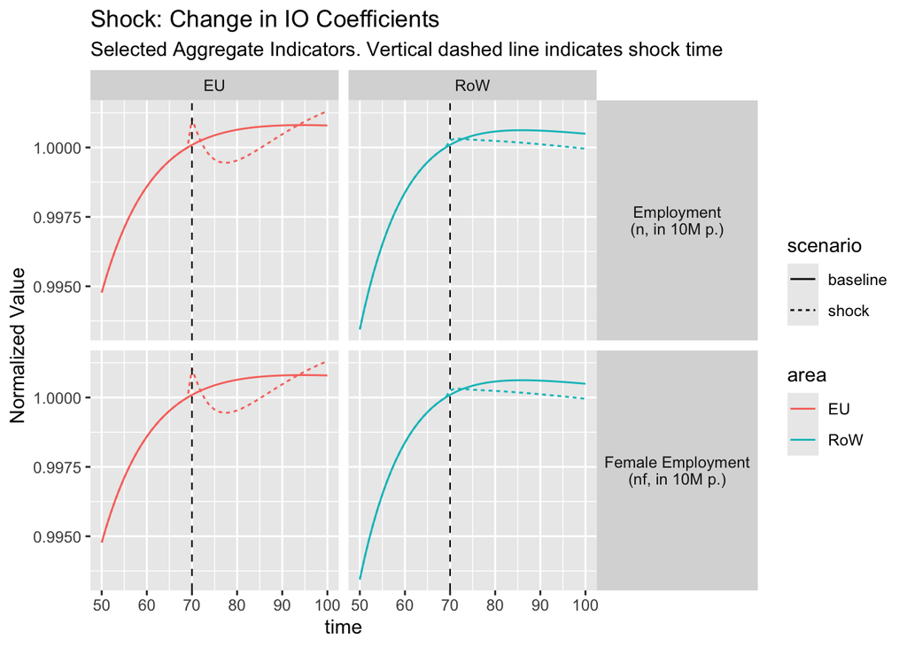

```r
# Employment
view.vars(data = df,
          viz.vars = c('n', 'nf'),
          var.label = 'Employment')
```

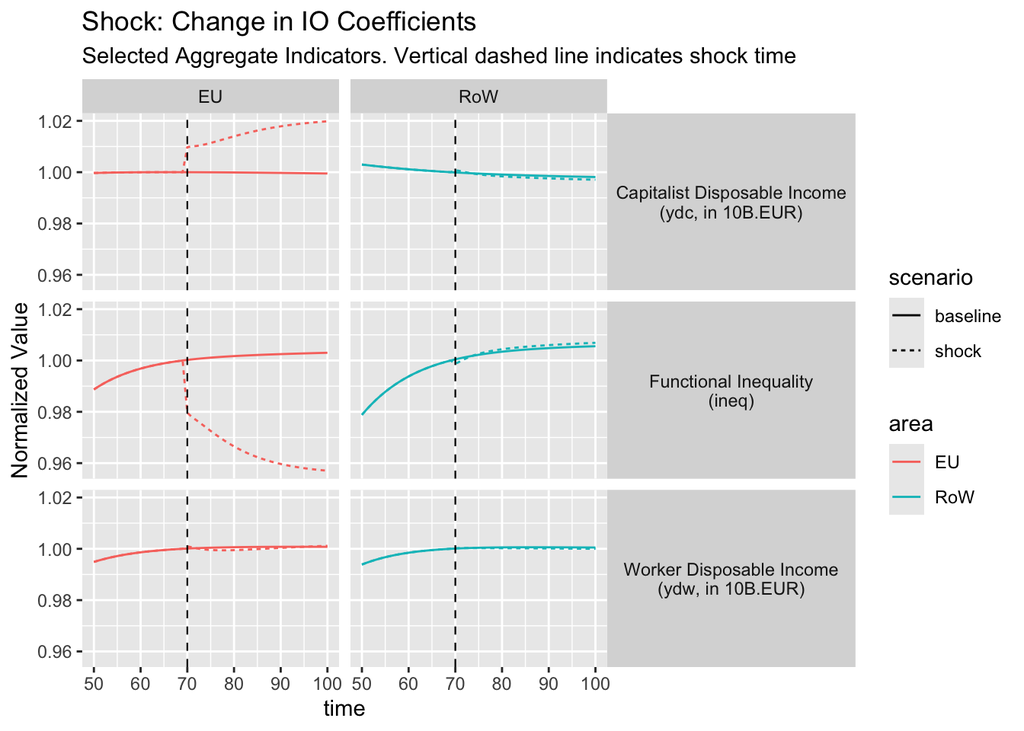

```r
# Inequality
view.vars(data = df,
          viz.vars = inequality.vars,
          var.label = 'Inequality')
```

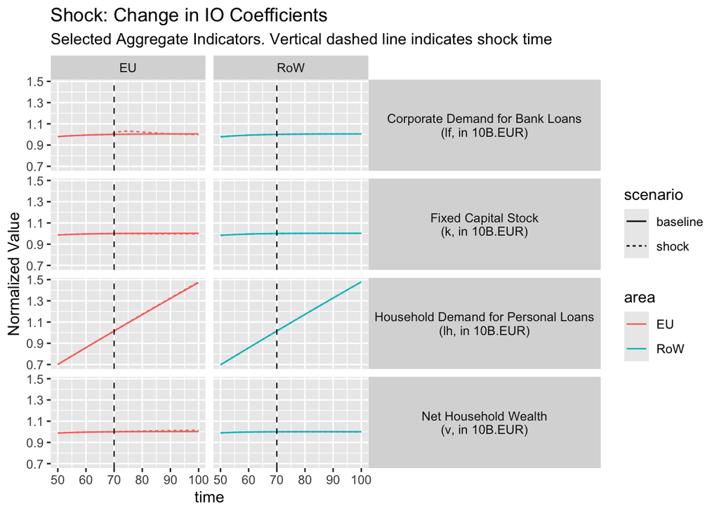

```r
# Debt and Wealth
view.vars(data = df,
          viz.vars = debt.wealth.vars,
          var.label = 'Financial Stocks')
```